# Lab 3 Team Work

Mike Zaino, mzaino16, & Meredith Tucker, mltucker2001

2/22/2020

```r
dat <- readxl::read_xls('C:/Users/mltuc/Documents/DS 202/ds202_lab3/GSS.xls')
predictors <- c("Year", "Jobsatif", "Happy", "Religion", "Education", "Addiction", "Cityproblems", "Space", "Party", "Race", "Sex", "Schoolyear", "Age", "Children", "Status", "ID", "Ballot")
names(dat) <- predictors
dat$Year <- as.factor(dat$Year)
```

# Mike Zaino Individual Work

1. How does the happiness of a respondent relate to the marriage status?

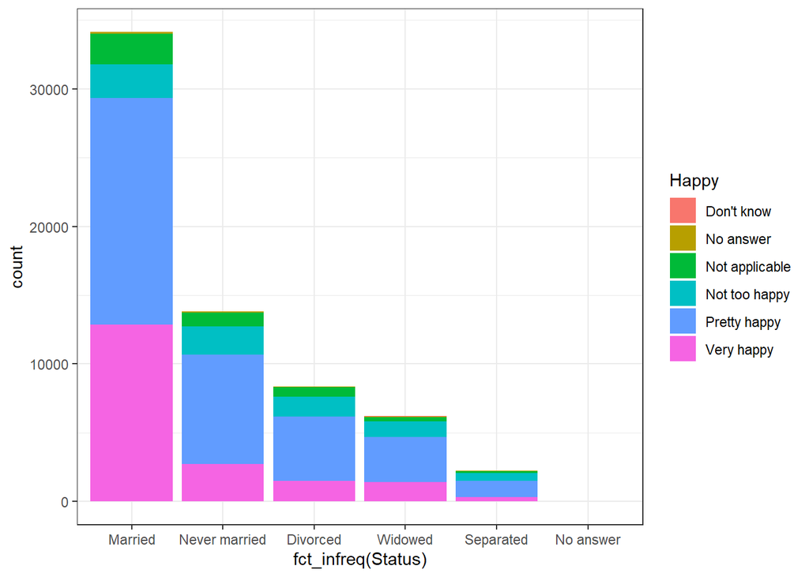

```r
ggplot(dat, aes(x=fct_infreq(Status), fill=Happy))+geom_bar()+theme_bw()
```

Yes, the percentage of people who are very happy and pretty happy who are married is highest compared to all other answers. So, yes, marriage does affect happiness.

2. Does the sex of the respondent affect the relationship you found in Q1?

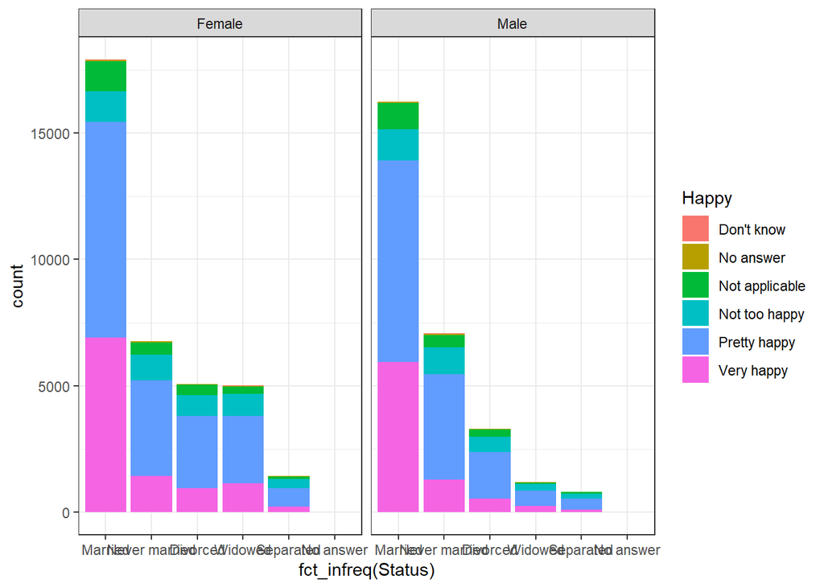

```r
ggplot(dat, aes(x=fct_infreq(Status), fill=Happy))+geom_bar()+theme_bw() +facet_wrap(~Sex)
```

No, it does not. Clearly from the above graph, males and females have about the same percentage of pretty happy and very happy people.

3. How does the happiness of a respondent relate to the political party affiliation?

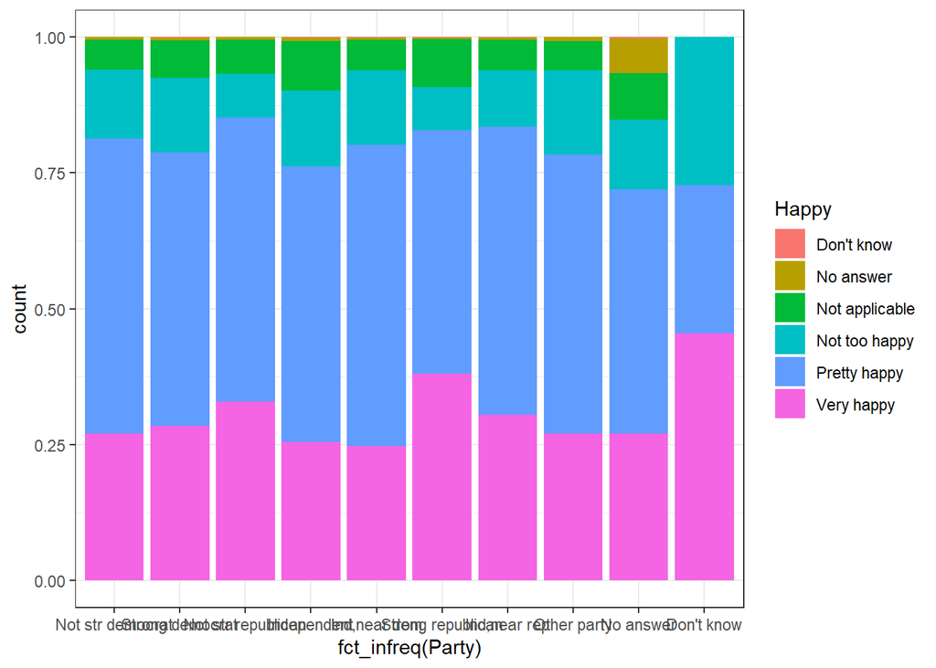

```r
ggplot(dat, aes(x=fct_infreq(Party), fill=Happy))+geom_bar(position="fill")+theme_bw()
```

Looking at the above graphs, it is tough to tell if there is a difference between parties. THere is small variations in the data but nothing to say one way or the other. So, political party has no affect on happiness.

# Meredith Tucker Problems 1 thru 3

1. How does the happiness of a respondent relate to the marriage status?

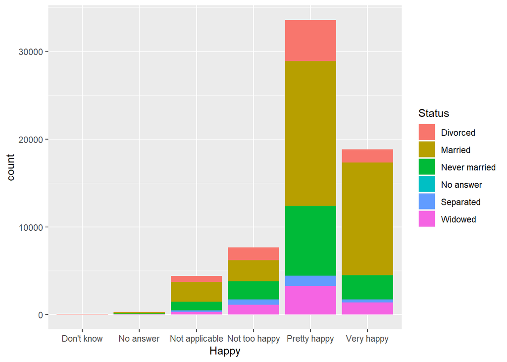

```r
ggplot(dat, aes(x=Happy, fill=Status)) + geom_bar()
```

2. Does the sex of the respondent affect the relationship you found in Q1?

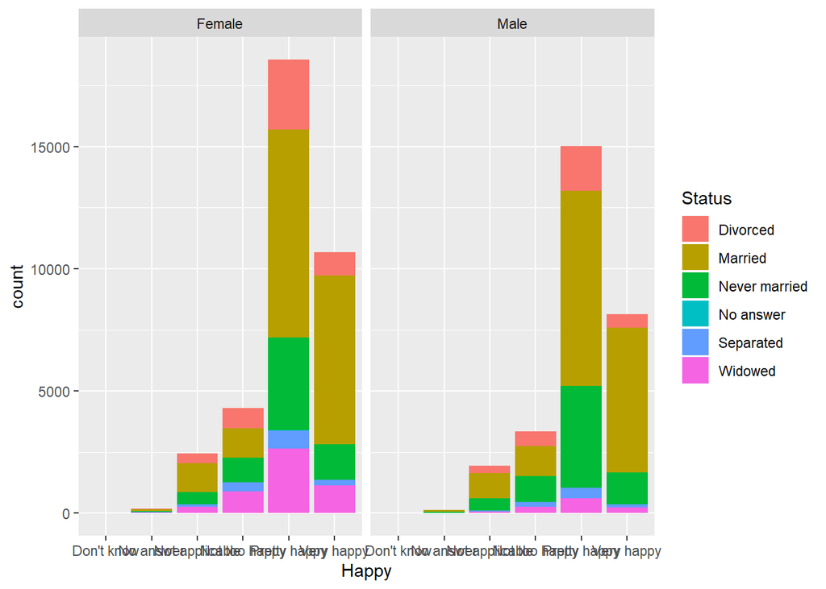

```r
ggplot(dat, aes(x=Happy, fill=Status)) +geom_bar() +facet_wrap(~Sex)
```

The level of women appear to be happier then the number of men. However there is a happier number of widowed women over the the number of widowed men.

3. How does the happiness of a respondent relate to the political party affiliation?

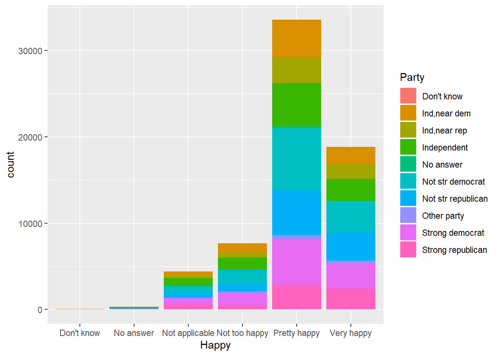

```r
ggplot(dat, aes(x=Happy, fill=Party)) + geom_bar()
```

I don’t believe that the party plays a large role on the happiness level. Most people say that they are happy.

# Team Work

1. Does your religion and political party association have any correlation?

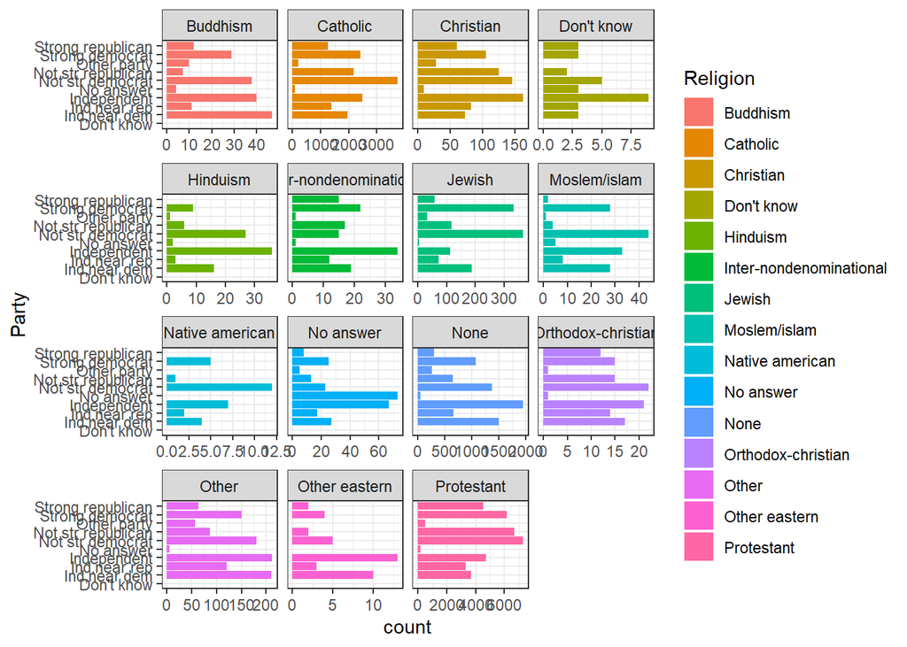

```r
ggplot(dat, aes(x=Party, fill=Religion))+geom_bar()+coord_flip()+theme_bw()+facet_wrap(~Religion, scales="free_x")
```

Looking at the graph, we can see that Protestant, Jewish, and Islam all favor democratic. This makes sense as their religion favors more democratic ideals. Catholic has more of an even spread across all the ideals. Lastly, the dont know category has a lot of independent people. This is because they do not favor any ideals and are in the middle of both republican and democrat.

2. Does your education level and party dictate views on the national education system?

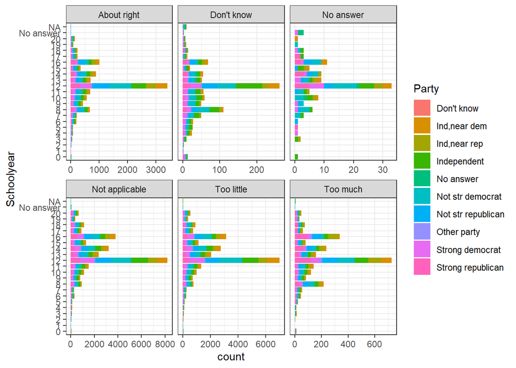

```r
dat$Schoolyear <- factor(dat$Schoolyear, levels = c('0','1','2','3','4','5','6','7','8','9','10','11','12','13','14','15','16','17','18','19','20', 'Dont know', 'No answer'))
ggplot(dat, aes(x=Schoolyear, fill=Party))+geom_bar()+theme_bw()+coord_flip()+facet_wrap(~Education, scales="free_x")
```

3. Does your religious preference determine your marital status and amount of children?

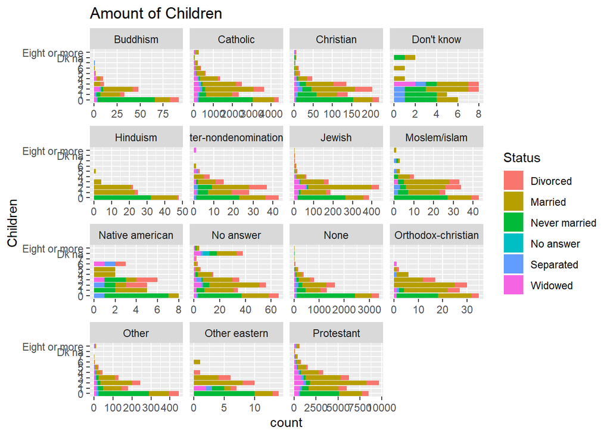

```r
ggplot(dat, aes(x=Children, fill=Status)) + geom_bar() + facet_wrap(~Religion, scales='free_x') + coord_flip() + labs( title='Amount of Children')
```

4. Is there a time when there was a political party affiliation shift?

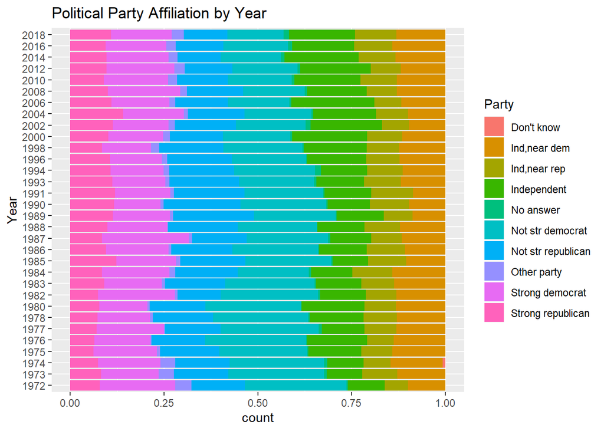

```r
ggplot(dat, aes(x=Year, fill=Party)) + geom_bar(position = 'fill') + coord_flip() + labs(title='Political Party Affiliation by Year')
```